# Scikit-learn and Natural Language

- Adapted from the scikit-learn tutorial and user guide at http://scikit-learn.org/.
- David M. Blei, [Probabilistic Topic Models](https://www.cs.princeton.edu/~blei/papers/Blei2012.pdf), Communications of the ACM, vol. 55, no. 4, pp. 77-84, April 2012.
- Mark Steyvers and Tom Griffiths, Probabilistic Topic Models, in T. Landauer, D McNamara, S. Dennis, W. Kintsch (eds), Latent Semantic Analysis: A Road to Meaning, Laurence Erlbaum, 2006.

> Panos Louridas, Associate Professor  
> Department of Management Science and Technology  
> Athens University of Economics and Business  
> louridas@aueb.gr

# Probabilities and Bayes' Rule

- Conditional probabilities are defined in terms of unconditional probabilities of events or propositions $a$ and $b$ as follows:

$$ P(a\, \vert\, b) = \frac{P(a \land b)}{P(b)} $$

- The above equation can also be written in the form of the *product rule*:

$$ P(a \land b) = P(a\, \vert\, b)P(b) $$

- When two propositions or events $a$ and $b$ are independent, we have:

$$ P(a\, \vert\, b) = P(a)$$$$ P(b\, \vert\, a) = P(b)$$$$ P(a \land b) = P(a)P(b)$$

- When we are talking about variables, not just events or propositions, we similarly have:

$$ P(X\, \vert\, Y) = P(X)$$$$ P(Y\, \vert\, X) = P(Y)$$$$ P(X, Y) = P(X)P(Y)$$

- The product rule can actually be written in two different ways: $$ P(a \land b) = P(a\, \vert\, b)P(b) $$ and $$ P(a \land b) = P(b\, \vert\, a)P(a) $$
- So combining the two forms we get: $$ P(b\, \vert\, a) = \frac{P(a\, \vert\, b)P(b)}{P(a)} $$ which is *Bayes' rule* (or Bayes' law, or Bayes' theorem).
- Equivalently we have for variables:

$$ P(Y\, \vert\, X) = \frac{P(X\, \vert\, Y)P(Y)}{P(X)} $$

- Baye's rule allows us to move from the *causal* direction to the *diagnostic* direction: $$ P(\textrm{cause}\, \vert\, \textrm{effect}) = \frac{P(\textrm{effect}\, \vert\, \textrm{cause}) P(\textrm{cause})}{P(\textrm{effect})} $$
- $P(\textrm{effect}\, \vert\, \textrm{cause})$ describes the causal direction.
- $P(\textrm{cause}\, \vert\, \textrm{effect})$ describes the diagnostic direction.
- In a medical setting, $$ P(\textrm{symptoms}\, \vert\, \textrm{disease})$$ gives the probability that symptoms arise from a certain disease; that is the causal direction.
- The doctor then wants to determine $$ P(\textrm{disease}\, \vert\, \textrm{symptoms}) $$ which is the probability that the patient suffers from a disease if the particular symptoms are exhibited.
- For example, a doctor knows that the disease meningitis causes the patient to have a stiff neck, say, 70% of the time.
- The doctor also knows some unconditional facts: the prior probability that a patient has meningitis is 1/50,000, and the prior probability that any patient has a stiff neck is 1%.
- Letting $s$ be the proposition that the patient has a stiff neck and $m$ be the proposition that the patient has meningitis, we have:

$$P(s\, \vert\, m) = 0.7$$$$P(m) = 1/50000$$$$P(s) = 0.01$$$$P(m\, \vert\, s) = \frac{P(s\, \vert\, m)P(m)}{P(s)} = \frac{0.7 \times 1/50000}{0.01} = 0.0014$$

# Naive Bayes Classification

- Suppose that we have a problem instance to be classified in one of $k$ classes, $C_k$, based on $x_1$, $x_2$, $\ldots$, $x_n$ features.
- That is equivalent to finding the maximum probability of: $$P(C_k\, \vert\, x_1, \dots, x_n)$$
- Applying Bayes rule we get:

$$P(C_k\, \vert\, x_1, \dots, x_n) = \frac{P(C_k) \ P(x_1, \dots, x_n\, \vert\, C_k)}{P(x_1, \dots, x_n)}$$

- Now, the denominator does not depend on $C_k$, so we can discard it in our quest to maximise the probability.
- Recall the chain rule of probability:

$$P(A_n, \ldots , A_1) = P(A_n\,\vert\, A_{n-1}, \ldots , A_1) \cdot P( A_{n-1}, \ldots , A_1)$$

- That means that the numerator is: $$P(C_k, x_1, \ldots, x_n)$$
- And by repeated application of the chain rule we get:

\begin{align} P(C_k, x_1, \dots, x_n) & = P(x_n \,\vert\, x_1, \dots, x_{n-1}, C_k)\ P( x_1, \dots, x_{n-1}, C_k)\\ & = P(x_n \,\vert\, x_1, \dots, x_{n-1}, C_k)\ P( x_{n-1} \,\vert\, x_1 \dots, x_{n-2}, C_k)\ P( x_1, \dots, x_{n-2}, C_k)\\ & = P(x_n \,\vert\, x_1, \dots, x_{n-1}, C_k)\ \dots \ P(x_2 \,\vert\, x_1, C_k) \ P(x_1, C_k) \\ & = P(x_n \,\vert\, x_1, \dots, x_{n-1}, C_k)\ \dots \ P(x_2 \,\vert\, x_1, C_k) \ P(x_1 \,\vert\, C_k)\ P(C_k) \\ & = P(C_k) \ P(x_1 \,\vert\, C_k) \ P(x_2 \,\vert\, C_k, x_1) \ \dots\ P(x_n \,\vert\, C_k, x_1, x_2, x_3, \dots, x_{n-1}) \end{align}

- This is where the "naive" part of the model comes into play.
- We assume that each of the $x_1$, $x_2$, $\ldots$, $x_n$ features is independent of all the others.
- So:

\begin{align} P(x_2 \,\vert\, C_k,x_1) & = P(x_2 \,\vert\, C_k)\\ P(x_3 \,\vert\, C_k,x_1, x_2) & = P(x_3\,\vert\, C_k)\\ \dots\\ P(x_n \,\vert\, C_k,x_1, \dots, x_{n-1}) & = P(x_n\,\vert\, C_k)\\ \end{align}

- This means that we have:

$$P(C_k\, \vert\, x_1, \dots, x_n) \propto P(C_k)\ P(x_1 | C_k) \dots\ P(x_n | C_k)$$

- Or:

$$ P(C_k\, \vert\, x_1, \dots, x_n) \propto P(C_k) \prod_{i = 1}^{n}{P(x_i \,\vert\, C_k)}$$

- We can use that to build a classifier that assigns as class to an instance. In particular, the classifier will choose the class that maximises the value of the above function. $$ \underset{k \in \{1, \dots, K\}}{\operatorname{argmax}} \ P(C_k) \displaystyle\prod_{i=1}^n P(x_i \,\vert\, C_k)$$
- To find the classifier we need to know the distribution of the probabilities $P(x_i \,\vert\, C_k)$.
- If $x = (x_1, \dots, x_n)$, and $P(x \,\vert\, C_k)$ follows the multinomial distribution, then the classifier we use is the *multinomial naive Bayes classifier*.

# Bernoulli, Binomial, Multinomial

- But what exactly is the multinomial distribution?
- It's worth spending some time to explore it, starting from the basics.

## Bernoulli

- If $X$ is a random variable that can take the value 1 with probability $p$ and the value 0 with probability $q = 1 - p$, then $X$ follows the Bernoulli distribution:

$$\Pr(X=1) = 1 - \Pr(X=0) = 1 - q = p$$

- The probability mass function of the Bernoulli distribution is:

$$f(x;p)={ \begin{cases} p & {\text{if }}x=1, \\[6pt]1-p & {\text{if }}x=0. \end{cases} }$$

- This can also be expressed as:

$$f(x;p)=p^{x}(1-p)^{1-x}\!\quad {\text{for }}x\in \{0,1\}$$

## Binomial

- If we have $n$ independent random variables, where each one of them can take the value 1 (success) with probability $p$ and the value 0 (failure) with probability $q = 1 - p$, then the probability that we will have $k$ successes is given by the Binomial distribution:

$$f(k;n,p)=\Pr(X=k)={\binom {n}{k}}p^{k}(1-p)^{n-k}$$

- This is equivalent to the probability that we will get $k$ successes in $n$ trials, where each trial is independent of the others and follows the Bernoulli distribution.
- So, the Bernoulli distribution is equal to the Binomial distribution for $n = 1$.

# Multinomial

- If we have $n$ independent random variables, where each one of them can take a value from $1, 2, \ldots, k$ with probability $p_k$, then the probability that we will get $x_1$ variables with value 1, $x_2$ variables with value 2, $\ldots$, $x_k$ variables with value $k$:

$$ \begin{aligned} f(x_{1},\ldots ,x_{k};n,p_{1},\ldots ,p_{k})&{}=\Pr(X_{1}=x_{1}{\text{ and }} X_{2} = x_{2}{\text{ and }} \dots {\text{ and }}X_{k}=x_{k})\\ &{}= \frac{n!}{x_{1}x_{2}!\cdots x_{k}!}p_{1}^{x_{1}}\cdots p_{k}^{x_{k}}\\ &{}= \binom{n!}{x_{1}, x{_2}, \ldots x_{k}}p_{1}^{x_{1}}\cdots p_{k}^{x_{k}} \end{aligned}$$

- The expression: $$\binom{n!}{x_{1}, x{_2}, \ldots, x_{k}}$$ is the *multinomial coefficient*. It is the number of ways to partition $n$ objects to $k$ groups of size $x_1, x_2, \ldots, x_k$.
- For example, if we roll one die six times, what is the probability that we will get 3 ones, 2 twos and 1 threes?
- It will be:

$$ f(3, 2, 1, 0, 0, 0; 6, 1/6, 1/6, 1/6, 1/6, 1/6, 1/6) = \frac{6!}{3! 2! 1! 0! 0! 0!}(1/6)^6 = \frac{5}{3888}$$

# Classification of Newsgroup Postings

- We'll use the above to train a classifier on a set of newsgroup postings.
- The example data set is the [Twenty Newsgroup](http://qwone.com/~jason/20Newsgroups/) dataset.
- It is a collection of approximately 20,000 newsgroup documents, partitioned (nearly) evenly across 20 different newsgroups.
- In order to get faster execution times for this first example we will work on a partial dataset with only 4 categories out of the 20 available in the dataset.

```python
categories = ['alt.atheism', 'soc.religion.christian',
              'comp.graphics', 'sci.med']
```

- We can now load the list of *training* files matching those categories.
- We use part of our dataset for training, and a separate part later on for testing.

```python
from sklearn.datasets import fetch_20newsgroups

twenty_train = fetch_20newsgroups(subset='train',
                                  categories=categories,
                                  shuffle=True,
                                  random_state=42)
```

- The returned dataset is a scikit-learn “bunch”.
- That is a simple holder object with fields that can be both accessed as python dict keys or object attributes for convenience.
- For instance, the `target_names` holds the list of the requested category names.

```python
twenty_train.target_names
```

```
['alt.atheism', 'comp.graphics', 'sci.med', 'soc.religion.christian']
```

- The files themselves are loaded in memory in the `data` attribute.
- For reference the filenames are also available.

```python
print(len(twenty_train.data))
print(len(twenty_train.filenames))
```

```
2257
2257
```

- To get a feeling of what we are dealing with, let's print the filename, first ten lines, and the category of the first file we downloaded.

```python
print(twenty_train.filenames[0])
print("\n".join(twenty_train.data[0].split("\n")[:10]))
print(twenty_train.target_names[twenty_train.target[0]])
```

```
/Users/panos/scikit_learn_data/20news_home/20news-bydate-train/comp.graphics/38440
From: sd345@city.ac.uk (Michael Collier)
Subject: Converting images to HP LaserJet III?
Nntp-Posting-Host: hampton
Organization: The City University
Lines: 14

Does anyone know of a good way (standard PC application/PD utility) to
convert tif/img/tga files into LaserJet III format.  We would also like to
do the same, converting to HPGL (HP plotter) files.

comp.graphics
```

- Our problem is an instance of supervised learning. We have the training set with the assigned categories.
- The category is the name of the newsgroup which also happens to be the name of the folder holding the individual documents.
- For reasons of speed and space efficiency, scikit-learn loads the target attribute as an array of integers that corresponds to the index of the category name in the `target_names` list.
- The category integer id of each sample is stored in the `target` attribute:

```python
twenty_train.target[:10]
```

```
array([1, 1, 3, 3, 3, 3, 3, 2, 2, 2])
```

- We can easily get the corresponding category names.

```python
[ twenty_train.target_names[i] for i in twenty_train.target[:10]]
```

```
['comp.graphics',
 'comp.graphics',
 'soc.religion.christian',
 'soc.religion.christian',
 'soc.religion.christian',
 'soc.religion.christian',
 'soc.religion.christian',
 'sci.med',
 'sci.med',
 'sci.med']
```

# The Bag-of-Words Model

- In language processing, we often model documents using the *bag-of-words* model.
- In this model, we use a *bag*, a.k.a a *multiset*, to represent each document.
- The bag contains, for the document, the counts of words that occur in the document, disregarding order, syntax, and grammar.
- As [an example](https://en.wikipedia.org/wiki/Bag-of-words_model), suppose we have the following two documents.

```
(1) John likes to watch movies. Mary likes movies too.

(2) John also likes to watch football games.
```

- Here is the list of the words that appear in these two documents.

```
[
    "John",
    "likes",
    "to",
    "watch",
    "movies",
    "also",
    "football",
    "games",
    "Mary",
    "too"
]
```

- And this is the bag-of-words representation for the two documents.

```
(1) [1, 2, 1, 1, 2, 0, 0, 0, 1, 1]
(2) [1, 1, 1, 1, 0, 1, 1, 1, 0, 0]
```

- In each list, item *i* corresponds to the *i*th word. The value of item *i* is the number of times it occurs in the particular document.
- We can understand the bag-of-words representation as a matrix.
  - We assign a fixed integer id to each word occurring in any document of the training set (for instance by building a dictionary from words to integer indices).
  - For each document `i`, we count the number of occurrences of each word `w` and store it in a matrix `X[i, j]` as the value of feature `j` where `j` is the index of word `w` in the dictionary.
- The bags of words representation implies that `n_features` is the number of distinct words in the corpus: this number is typically larger that 100,000.
- If `n_samples == 10000`, storing `X` as a numpy array of type float32 would require 10000 x 100000 x 4 bytes = 4GB in RAM.
- Fortunately, most values in `X` will be zeros since for a given document less than a couple thousands of distinct words will be used.
- For this reason we say that bags of words are typically high-dimensional sparse datasets. We can save a lot of memory by only storing the non-zero parts of the feature vectors in memory.
- For this reason, scikit-learn uses *sparse matrices* provided by `scipy.sparse`.
- What we have been calling words are actually *tokens* in language processing parlance.
- We need a mechanism to break our documents into tokens and count them.
- This is the job of `CountVectorizer`.

```python
from sklearn.feature_extraction.text import CountVectorizer

vectorizer = CountVectorizer(min_df=1)
vectorizer
```

```
CountVectorizer(analyzer='word', binary=False, decode_error='strict',
        dtype=<class 'numpy.int64'>, encoding='utf-8', input='content',
        lowercase=True, max_df=1.0, max_features=None, min_df=1,
        ngram_range=(1, 1), preprocessor=None, stop_words=None,
        strip_accents=None, token_pattern='(?u)\\b\\w\\w+\\b',
        tokenizer=None, vocabulary=None)
```

- Let’s use it to tokenize and count the word occurrences of a minimalistic corpus of text documents.
- `CountVectorizer` has an interface similar to other classes in scikit-learn; that means that we start with a `fit` and then we do a `transform`.
- The `fit` method learns a vocabulary dictionary of all tokens in the raw documents.

```python
corpus = [
    'This is the first document.',
    'This is the second second document.',
    'And the third one.',
    'Is this the first document?',
]

vectorizer.fit(corpus)
```

```
CountVectorizer(analyzer='word', binary=False, decode_error='strict',
        dtype=<class 'numpy.int64'>, encoding='utf-8', input='content',
        lowercase=True, max_df=1.0, max_features=None, min_df=1,
        ngram_range=(1, 1), preprocessor=None, stop_words=None,
        strip_accents=None, token_pattern='(?u)\\b\\w\\w+\\b',
        tokenizer=None, vocabulary=None)
```

- Then the `transform` method transforms documents to document-term matrix form.
- It extracts token counts out of raw text documents using the vocabulary fitted with `fit` or the one provided to the constructor.

```python
X = vectorizer.transform(corpus)
X
```

```
<4x9 sparse matrix of type '<class 'numpy.int64'>'
	with 19 stored elements in Compressed Sparse Row format>
```

- However, `CountVectorizer` also offers the fit_transform method that returns the bag-of-words representation directly and more efficiently than doing the two separate calls.

```python
X = vectorizer.fit_transform(corpus)
X
```

```
<4x9 sparse matrix of type '<class 'numpy.int64'>'
	with 19 stored elements in Compressed Sparse Row format>
```

- The bag-of-words is a sparse matrix represented in CSR (= Compressed Sparse Row) format.
- The CSR format means that we store the contents of the sparse matrix using three arrays.
  - The array `data` (called A in the literature) holds the actual values stored in the matrix.
  - The array `indptr`(called IA in the literature) has $m+1$ elements, where $m$ is the number of rows in the non-sparse matrix. `indptr[i]` gives the index of the first element of row `i` in `data`. That means that the elements of row `i` in `data` extend from `indptr[i]` to `indptr[i+1] - 1`.
  - The array `indices` (called JA in the literature) holds the column index of each element in A and is therefore the same size with A.

```python
print('Non-sparse array', end='\n\n')
print(X.toarray(), end='\n\n')

print('CSR array')
print()
print('data: ', X.data)
print('indptr: ', X.indptr)
print('indices ', X.indices)
```

```
Non-sparse array

[[0 1 1 1 0 0 1 0 1]
 [0 1 0 1 0 2 1 0 1]
 [1 0 0 0 1 0 1 1 0]
 [0 1 1 1 0 0 1 0 1]]

CSR array

data:  [1 1 1 1 1 2 1 1 1 1 1 1 1 1 1 1 1 1 1]
indptr:  [ 0  5 10 14 19]
indices  [1 2 6 3 8 5 1 6 3 8 4 7 0 6 1 2 6 3 8]
```

- The interpretation of the columns can be found with the `get_feature_names` method.

```python
vectorizer.get_feature_names()
```

```
['and', 'document', 'first', 'is', 'one', 'second', 'the', 'third', 'this']
```

- The converse mapping from feature name to column index is stored in the `vocabulary_` attribute.

```python
vectorizer.vocabulary_
```

```
{'and': 0,
 'document': 1,
 'first': 2,
 'is': 3,
 'one': 4,
 'second': 5,
 'the': 6,
 'third': 7,
 'this': 8}
```

- After we have fitted a vectorizer with our corpus, we can use it to transform other documents as well.
- Since it has used the particular corpus, we can verify that the bag-of-words of a document with words not found in the corpus will be a matrix of zeros.

```python
vectorizer.transform(['Something completely new.']).toarray()
```

```
array([[0, 0, 0, 0, 0, 0, 0, 0, 0]])
```

- Returning to the tokenisation process, the default configuration tokenizes strings by extracting words of at least 2 letters. The specific function that does this step can be requested explicitly.

```python
analyze = vectorizer.build_analyzer()
analyze("This is a text document to analyze.")
```

```
['this', 'is', 'text', 'document', 'to', 'analyze']
```

- Note that in the previous corpus, the first and the last documents have exactly the same words hence are encoded in equal vectors.
- In particular we lose the information that the last document is an interrogative form.
- To preserve some of the local ordering information we can extract 2-grams of words in addition to the 1-grams (individual words).

```python
bigram_vectorizer = CountVectorizer(ngram_range=(1, 2),
                                    token_pattern=r'\b\w+\b', min_df=1)
analyze = bigram_vectorizer.build_analyzer()
analyze('Bi-grams are cool!')
```

```
['bi', 'grams', 'are', 'cool', 'bi grams', 'grams are', 'are cool']
```

- We can use the `bigram_vectorizer` on the original corpus.

```python
X_2 = bigram_vectorizer.fit_transform(corpus).toarray()
X_2
```

```
array([[0, 0, 1, 1, 1, 1, 1, 0, 0, 0, 0, 0, 1, 1, 0, 0, 0, 0, 1, 1, 0],
       [0, 0, 1, 0, 0, 1, 1, 0, 0, 2, 1, 1, 1, 0, 1, 0, 0, 0, 1, 1, 0],
       [1, 1, 0, 0, 0, 0, 0, 0, 1, 0, 0, 0, 1, 0, 0, 1, 1, 1, 0, 0, 0],
       [0, 0, 1, 1, 1, 1, 0, 1, 0, 0, 0, 0, 1, 1, 0, 0, 0, 0, 1, 0, 1]], dtype=int64)
```

- We can verify that the interrogative form "Is this" is only present in the last document.

```python
feature_index = bigram_vectorizer.vocabulary_['is this']
print(feature_index)
X_2[:, feature_index]
```

```
7
```

```
array([0, 0, 0, 1], dtype=int64)
```

- Let's return now to the twenty newsgroups dataset.
- We'll run a `CountVectorizer` on it.

```python
count_vect = CountVectorizer()
X_train_counts = count_vect.fit_transform(twenty_train.data)
X_train_counts.shape
```

```
(2257, 35788)
```

# tf-idf

- Occurrence counts is simple and makes for a good start, but there are problems when we are dealing with large documents.
- Terms in large documents will display higher frequency counts, even if the documents talk about the same topics.
- To get around this problem we can go beyond frequency counts and use the *tf-idf* metric.
- The tf metric stands for *term frequency*.
- The simplest way to calculate tf is simply as the raw frequency of a term in a document, i.e., the number of times that term *t* occurs in document *d*.
- The idf metric stands for *inverse document frequency*.
- The idf measures how much information a term provides, that is, how common is a term inside a document corpus. $$\mathrm{idf}(t, D) = \log \frac{N}{|\{d \in D: t \in d\}|}$$
- In the above formula:
  - $D$ is the document corpus.
  - $N$ is the total number of documents in the corpus, $N = {|D|}$
  - $|\{d \in D: t \in d\}|$ : number of documents where the term $t$ appears (i.e., $\mathrm{tf}(t,d) \neq 0)$.
- If a term does not appear in the corpus, this will lead to division by zero, so we often adjust it by adding one to the denominator: $$\mathrm{idf}(t, D) = \log \frac{N}{1 + |\{d \in D: t \in d\}|}$$
- With idf we downscale weights for words that occur in many documents in the corpus and are therefore less informative than those that occur only in a smaller portion of the corpus.
- We therefore arrive at the tf-idf metric: $$\textrm{tf-idf}(t,d,D) = \mathrm{tf}(t,d) \times \mathrm{idf}(t, D)$$
- In fact, scikit-learn uses a slightly different variant: $$\textrm{tf-idf}(t,d,D) = \mathrm{tf}(t,d) \times (\mathrm{idf}(t, D) + 1) = \mathrm{tf} + \mathrm{tf} \times \mathrm{idf}$$
- We add one so that terms with zero idf, i.e. that occur in all documents of a training set, will not be entirely ignored.
- After we calculate the tf-idf, we want to make sure that documents with similar content look indeed similar, even though one may be much longer than the other.
- Since the similarity between two documents is represented by the tf-idf vector for that document, we want to scale the vector down so that all documents have the same unit norm.
- All these transformations are implemented by the `TfidfTransformer` class.

```python
from sklearn.feature_extraction.text import TfidfTransformer
transformer = TfidfTransformer()
transformer
```

```
TfidfTransformer(norm='l2', smooth_idf=True, sublinear_tf=False, use_idf=True)
```

- Let’s take an example with the following counts.
- The first term is present 100% of the time hence not very interesting.
- The other two features occur only in less than 50% of the time, hence they are probably more representative of the content of the documents.

```python
counts = [[3, 0, 1],
          [2, 0, 0],
          [3, 0, 0],
          [4, 0, 0],
          [3, 2, 0],
          [3, 0, 2]]

transformer.fit(counts)
tfidf = transformer.transform(counts)
tfidf
```

```
<6x3 sparse matrix of type '<class 'numpy.float64'>'
	with 9 stored elements in Compressed Sparse Row format>
```

- We can convert back to the original array to see how the counts have been affected.

```python
tfidf.toarray()
```

```
array([[ 0.85151335,  0.        ,  0.52433293],
       [ 1.        ,  0.        ,  0.        ],
       [ 1.        ,  0.        ,  0.        ],
       [ 1.        ,  0.        ,  0.        ],
       [ 0.55422893,  0.83236428,  0.        ],
       [ 0.63035731,  0.        ,  0.77630514]])
```

- We mentioned that all feature vectors will have the same magnitude.
- This is done by normalizing with the $\ell^2$ (Euclidean) norm.
- If $x = (x_1, \dots, x_n)$ then: $$\left\| x \right\| = \sqrt{x_1^2 + \cdots + x_n^2}$$
- The normalized vector is: $$\frac{x}{\left\| x \right\|}$$
- We can also use the $\ell_1$ norm, defined as:

$$\left\| x \right\| _1 := \sum_{i=1}^{n} \left| x_i \right|$$

- This is also known as Taxicab norm or Manhattan norm, because it relates to the distance a taxi has to drive in a rectangular street grid to get from the origin to the point $x$.
- If we want to get the idf values computed for each feature, we can do so via the `idf_` attribute of the transformer.

```python
transformer.idf_
```

```
array([ 1.        ,  2.25276297,  1.84729786])
```

- Up to now, we first used the `fit` method to fit our estimator to the data and then the `transform` method to transform our count-matrix to a tf-idf representation.
- These two steps can be combined to achieve the same end result faster by skipping redundant processing.
- This is done through using the `fit_transform` method.

```python
tfidf_transformer = TfidfTransformer()
X_train_tfidf = tfidf_transformer.fit_transform(X_train_counts)
X_train_tfidf.shape
```

```
(2257, 35788)
```

# Training a Classifier

- Now that we have our features, we can train a classifier to try to predict the category of a post.
- We'll use a naïve Bayes classifier.

```python
from sklearn.naive_bayes import MultinomialNB
clf = MultinomialNB().fit(X_train_tfidf, twenty_train.target)
```

- We can now try to predict the outcome on a new document we need to extract the features using almost the same feature extracting chain as before.
- The difference is that we call `transform` instead of `fit_transform` on the transformers, since they have already been fit to the training set.

```python
docs_new = ['God is love', 'OpenGL on the GPU is fast']
X_new_counts = count_vect.transform(docs_new)
X_new_tfidf = tfidf_transformer.transform(X_new_counts)

predicted = clf.predict(X_new_tfidf)

for doc, category in zip(docs_new, predicted):
    print('%r => %s' % (doc, twenty_train.target_names[category]))
```

```
'God is love' => soc.religion.christian
'OpenGL on the GPU is fast' => comp.graphics
```

# Building a Pipeline

- We show that we proceeded with the following steps:
  - vectorizer
  - transformer
  - classifier
- We can build a pipeline so that we can chain all of them together.

```python
from sklearn.pipeline import Pipeline
text_clf = Pipeline([('vect', CountVectorizer()),
                     ('tfidf', TfidfTransformer()),
                     ('clf', MultinomialNB()),
                    ])
```

- The names `vect`, `tfidf` and `clf` are arbitrary.
- We shall see their use in the section on grid search, in a bit.
- We can now train the model with a single command.

```python
text_clf = text_clf.fit(twenty_train.data, twenty_train.target)
```

# Evaluation of the Performance on the Test Set

- It is easy to evaluate the performance of our classifier.
- The evaluation is carried out using the holdout *test* data, which we did not use in the training phase.

```python
import numpy as np
twenty_test = fetch_20newsgroups(subset='test',
                                 categories=categories,
                                 shuffle=True,
                                 random_state=42)
docs_test = twenty_test.data
predicted = text_clf.predict(docs_test)
np.mean(predicted == twenty_test.target)
```

```
0.83488681757656458
```

- Let's also have a look at the *classification report* and the *confusion matrix*.
- Remember that the classification report displays the following metrics:
  - precision
  - recall
  - $F_1$ score
  - support, which is the number of instances reported in each class
- Precision is the ratio of true positives over all reported positives.
- Equivalently, it is the number of correct positive results divided by the number of positive results.
- Mathematically, it is: $$\text{precision} = \frac{TP}{TP + FP}$$
- Or, specifically, in information retrieval: $$\text{precision} = \frac{|\text{relevant documents|}\cap \text{|retrieved documents|}}{|\text{retrieved documents}|}$$
- Recall is the ratio of of true positives over all actual positives.
- Equivalently, it is the ratio of true positives over the sum of true positives and false negatives.
- Or, the number of correct positive results divided by the number of positive results that should have been returned.
- Mathematically, it is: $$\text{recall} = \frac{TP}{TP + FN}$$
- Or, specifically, in information retrieval: $$\text{recall} = \frac{|\text{relevant documents|}\cap \text{|retrieved documents|}}{|\text{relevant documents}|}$$
- It is also called *sensitivity*.
- We can understand it as the probability that a relevant document is retrieved.
- The $F_1$ score takes both the precision and the recall into account.
- Mathematically, it is the *harmonic mean* of the precision and the recall.
- The harmonic mean of $n$ numbers $x_1, x_2, \ldots, x_n$ is defined as:

$$H={\frac {n}{{\frac {1}{x_{1}}}+{\frac {1}{x_{2}}}+\cdots +{\frac {1}{x_{n}}}}}$$

- So, the $F_1$ score is:

$$F_{1}=2\cdot \frac{1}{\tfrac{1}{\mathrm{recall}}+\tfrac{1}{\mathrm{precision}}} = 2\cdot {\frac{\mathrm{precision} \cdot \mathrm{recall}}{\mathrm{precision} +\mathrm{recall}}}$$

```python
from sklearn import metrics

print(metrics.classification_report(twenty_test.target, predicted,
                                    target_names=twenty_test.target_names))
```

[output not shown]

- The confusion matrix is a matrix $C$ such that:
  - the entry in each cell $C[i, j]$ shows the number of observations that belong to class $i$ but are reported as being in class $j$.

```python
metrics.confusion_matrix(twenty_test.target, predicted)
```

[output not shown]

- By way of comparison, let's also check a classifier built on a Support Vector Machine (SVM).
- SVMs are very powerful, but slower than naive Bayes.

```python
from sklearn.linear_model import SGDClassifier
text_clf = Pipeline([('vect', CountVectorizer()),
                     ('tfidf', TfidfTransformer()),
                     ('clf', SGDClassifier(loss='hinge', penalty='l2',
                                           alpha=1e-3, n_iter=5,
                                           random_state=42))
                    ])
_ = text_clf.fit(twenty_train.data, twenty_train.target)
predicted = text_clf.predict(docs_test)
np.mean(predicted == twenty_test.target)
```

```
0.9127829560585885
```

- Again, let's also have a look at the classification report and the confusion matrix.

```python
from sklearn import metrics
print(metrics.classification_report(twenty_test.target, predicted,
                                    target_names=twenty_test.target_names))

print()
print(metrics.confusion_matrix(twenty_test.target, predicted))
```

```
                        precision    recall  f1-score   support

           alt.atheism       0.95      0.81      0.87       319
         comp.graphics       0.88      0.97      0.92       389
               sci.med       0.94      0.90      0.92       396
soc.religion.christian       0.90      0.95      0.93       398

           avg / total       0.92      0.91      0.91      1502


[[258  11  15  35]
 [  4 379   3   3]
 [  5  33 355   3]
 [  5  10   4 379]]
```

# Parameter Tuning Using Grid Search

- There are many parameters that affect the performance of our models. For example:
  - `use_idf` in `TfidfTransformer`
  - `MultinomialNB` includes a smoothing parameter `alpha`
  - `SGDClassifier` has a penalty parameter `alpha`
- Instead of tweaking the parameters of the various components of the chain, it is possible to run an exhaustive search of the best parameters on a grid of possible values.
- We try out all classifiers on either words or bigrams, with or without idf, and with a penalty parameter of either 0.01 or 0.001 for the linear SVM.
- We'll put the parameters of the search in a dictionary. Each key of the dictionary will be composed by the pipeline element followed by the parameter name. The values of each key will form the search space for the grid search.

```python
from sklearn.model_selection import GridSearchCV
parameters = {'vect__ngram_range': [(1, 1), (1, 2)],
              'tfidf__use_idf': (True, False),
              'clf__alpha': (1e-2, 1e-3)
             }
```

- Obviously, such an exhaustive search can be expensive.
- If we have multiple CPU cores at our disposal, we can tell the grid searcher to try these eight parameter combinations in parallel with the `n_jobs` parameter.
- If we give this parameter a value of -1, grid search will detect how many cores are installed and uses them all.

```python
gs_clf = GridSearchCV(text_clf, parameters, n_jobs=-1)
```

- The grid search instance behaves like a normal scikit-learn model.
- We start by calling its `fit` method.

```python
gs_clf = gs_clf.fit(twenty_train.data, twenty_train.target)
```

- The result of calling fit on a GridSearchCV object is a classifier that we can use to predict.

```python
twenty_train.target_names[gs_clf.predict(['God is love'])[0]]
```

```
'soc.religion.christian'
```

- We can get the estimator values found by grid search with the `best_estimator_` attribute, but this can be unwieldy.

```python
gs_clf.best_estimator_
```

```
Pipeline(steps=[('vect', CountVectorizer(analyzer='word', binary=False, decode_error='strict',
        dtype=<class 'numpy.int64'>, encoding='utf-8', input='content',
        lowercase=True, max_df=1.0, max_features=None, min_df=1,
        ngram_range=(1, 1), preprocessor=None, stop_words=None,
        strip...     penalty='l2', power_t=0.5, random_state=42, shuffle=True, verbose=0,
       warm_start=False))])
```

- It is much easier to get the best parameters directly by using the `best_params_` attribute.

```python
gs_clf.best_params_
```

```
{'clf__alpha': 0.001, 'tfidf__use_idf': True, 'vect__ngram_range': (1, 1)}
```

# Feature Hashing

- The mapping from tokens to integers that we have been using is simple and works well in many cases.
- However, we need to hold in memory the mapping from the string tokens to the integer feature indices.
- This is what we saw with the `vocabulary_` attribute.
- This has problems with big datasets.
- The larger the corpus, the larger the vocabulary will grow and hence the memory use too.
- Building the word-mapping requires a full pass over the dataset hence it is not possible to fit text classifiers in a strictly online manner.
- To get arround this problem, we can use the [hashing trick](https://en.wikipedia.org/wiki/Feature_hashing).
- In particular, we apply a hash function to the features and use their hash values as indices directly, rather than looking the indices up in an associative array.
- To achieve that, we use the `FeatureHasher` class.
- Instances of `FeatureHasher` apply a hash function to the features to determine their column index in sample matrices directly.
- The result is increased speed and reduced memory usage, at the expense of inspectability; the hasher does not remember what the input features looked like and has no `inverse_transform` method.

```python
def hashing_vectorizer(features, n):
    v = np.zeros(n, dtype=int)
    for f in features:
        h = hash(f)
        v[h % n] += 1
    return v
```

- For instance, suppose a document has the following features: `['cat', 'dog', 'man', 'woman']`.
- And also suppose that we expect our total vocabulary to be of size 10.
- Then the result of the `hashing_vectorizer` will be:

```python
features = ['cat', 'dog', 'man', 'woman']
v = hashing_vectorizer(features, 10)
print(v)
```

```
[0 0 0 0 1 0 0 2 0 1]
```

- Since the hash function might cause collisions between (unrelated) features, a signed hash function is used and the sign of the hash value determines the sign of the value stored in the output matrix for a feature.
- This way, collisions are likely to cancel out rather than accumulate error, so that the hash function is unbiased.
- If `non_negative=True` is passed to the constructor, the absolute value is taken.
- This undoes some of the collision handling, but allows the output to be passed to estimators like `MultinomialNB`.

```python
import mmh3

def hashing_vectorizer(features, n):
    v = np.zeros(n, dtype=int)
    for f in features:
        h = mmh3.hash(f)
        idx = h % n
        if h < 1 == 1:
            v[idx] += 1
        else:
            v[idx] -= 1
    return v

v = hashing_vectorizer(features, 10)
print(v)
```

```
[-1  0 -1  0  0  0  0  1  0 -1]
```

- Feature hashing can be employed in document classification, but unlike `CountVectorizer`, `FeatureHasher` does not do word splitting or any other preprocessing except Unicode-to-UTF-8 encoding.
- So we either need to write our own tokenizer, or we can use `HashingVectorizer`, which is a combined tokenizer/hasher.
- `HashingVectorizer` is stateless, so we do not need to call `fit` on it; we just call `transform` directly.
- In practice collisions are rarely a problem, because the hash table is to the order of $2^{18}$, so collisions are likely to be rare.
- The size of the hash table can be adjusted with the `n_features` parameter; a small `n_features` value can lead to collisions.

```python
from sklearn.feature_extraction.text import HashingVectorizer

hv = HashingVectorizer(n_features=10)
hv.transform(corpus)
```

```
<4x10 sparse matrix of type '<class 'numpy.float64'>'
	with 16 stored elements in Compressed Sparse Row format>
```

- You can see that 16 non-zero feature tokens were extracted in the vector output.
- This is less than the 19 non-zeros extracted previously by the CountVectorizer on the same toy corpus.
- The discrepancy comes from hash function collisions because of the low value of the `n_features` parameter.
- Since `HashingVectorizer` is stateless, it does not provide idf weighting as that would introduce statefulness in the model.
- To do that we need to append a `TfidfTransformer` in a pipeline.
- Let's run our example using `HashingVectorizer`.

```python
text_clf = Pipeline([('vect', HashingVectorizer()),
                     ('tfidf', TfidfTransformer()),
                     ('clf', SGDClassifier(loss='hinge', penalty='l2',
                                           alpha=1e-3, n_iter=5,
                                           random_state=42))
                    ])
_ = text_clf.fit(twenty_train.data, twenty_train.target)
predicted = text_clf.predict(docs_test)
print(np.mean(predicted == twenty_test.target))
print()

print(metrics.classification_report(twenty_test.target, predicted,
                                    target_names=twenty_test.target_names))

print()
print(metrics.confusion_matrix(twenty_test.target, predicted))
```

```
0.904127829561

                        precision    recall  f1-score   support

           alt.atheism       0.97      0.80      0.87       319
         comp.graphics       0.84      0.98      0.90       389
               sci.med       0.94      0.87      0.90       396
soc.religion.christian       0.91      0.95      0.93       398

           avg / total       0.91      0.90      0.90      1502


[[255  16  14  34]
 [  2 382   3   2]
 [  2  47 344   3]
 [  5  12   4 377]]
```

# Latent Dirichlet Allocation

- The Latent Dirichlet Allocation (LDA) is a very popular method for identifying topics in documents (and not only).
- It assumes that documents are generated through a probabilistic generative process.
- To gain some insight inside the generative process, we need to understand the *Dirichlet distribution* (which gives the name to LDA). To do that, we should first have a look at the *Beta distribution*.

## The Beta Distribution

- We know that if we have a coin that comes up heads with probabity $p$, then the probability that we will have $k$ heads out of $n$ coin tosses is given by the Binomial distribution:

$$f(k;n,p)=\Pr(X=k)={\binom {n}{k}}p^{k}(1-p)^{n-k}$$

- But suppose that we do not know exactly the probability $p$; suppose instead that we know, from prior history, that the coin had $a$ heads and $b$ tails.
- Based on this prior knowledge we want to select a $p$ that is consistent with these prior results.
- It turns out that a distribution that would fit our needs is of the form: $$f(x; a, b) = \text{constant}\cdot x^{a-1} (1-x)^{b-1}$$
- The constant is neede to ensure that the total probability integrates to 1. So it is: $$ \text{constant} = \frac{1}{\int_{0}^{1}u^{a-1}(1-u)^{b-1}\mathrm{du}} $$
- But then, by definition: $$ \int_{0}^{1}u^{a-1}(1-u)^{b-1}\mathrm{du} = \text{B}(a, b)$$
- So we arrive at the Beta distribution: $$\text{Beta}(x; a, b) = \frac{1}{\text{B}(a, b)}x^{a-1} (1-x)^{b-1}$$
- The mean of Beta is: $$\frac{a}{a+b}$$ and the variance is: $$\frac{ab}{(a + b)^2(a + b + 1)}$$
- Note that: $$\text{B}(a, b) = \frac{\Gamma(a)\Gamma(b)}{\Gamma(a + b)}$$
- So we have:

$$\text{Beta}(x; a, b) = \frac{\Gamma(a + b)}{\Gamma(a)\Gamma(b)}x^{a-1} (1-x)^{b-1}$$

- And what is this mysterious $\Gamma(\cdot)$ function?
- It is the generalisation of the factorial function to complex (and therefore real) numbers.
- It is: $$\Gamma (z)=\int _{0}^{\infty }x^{z-1}e^{-x}\,\mathrm {d} x$$
- From which it follows that for any natural number $n$: $$\Gamma(n) = (n - 1)!$$

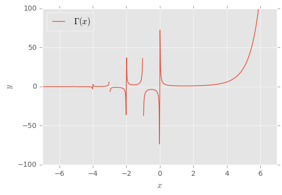

```python
import matplotlib.pyplot as plt
%matplotlib inline

plt.style.use('ggplot')

from scipy.special import gamma as Gamma

x = np.linspace(-7, 7, 512)
y = Gamma(x)

plt.plot(x, y, label=r'$\Gamma(x)$')

plt.xlabel('$x$')
plt.ylabel('$y$')
plt.axis([-7, 7, -100, 100])
plt.legend(loc='best')
```

- Back to the Beta distribution, here it is for different values of $a$ and $b$:

[figure not shown]

```python
from scipy.stats import beta
import numpy as np

def draw_beta(a, b, style, ylim):
    x = np.linspace(beta.ppf(0.00, a, b),
                    beta.ppf(1, a, b),
                    100)
    plt.ylim(ylim)
    plt.plot(x, beta.pdf(x, a, b), style,
             alpha=0.6,
             label='$a = %d,\ b = %d$' %(a, b))

ylim = (0, 3)
draw_beta(0.5, 0.5, 'r-', ylim)
draw_beta(5, 1, 'b-', ylim)
draw_beta(1, 3, 'c-', ylim)
draw_beta(2, 2, 'g-', ylim)
draw_beta(2, 5, 'm-', ylim)

plt.legend(bbox_to_anchor=(1.35, 0.5))
```

- Now, the Beta distribution can be used as a basis for Bayesian inference.
- Suppose that in our original setting with the coin we had $a = 11$ and $b = 23$.
- Then we would use $\text{Beta}(11, 23)$ to pick a value for $p$.
- The mean of $\text{Beta}(11, 23)$ is $a / (a + b) = 0.32$.
- So, we'll be picking a value of $p$ centered around 0.32.

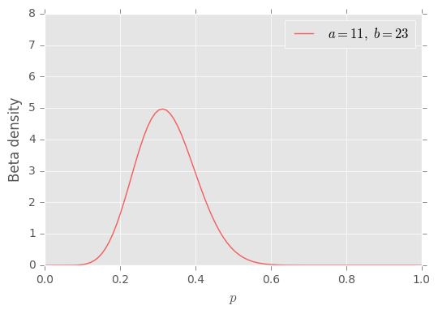

```python
ylim = (0, 8)
draw_beta(11, 23, 'r-', ylim)
plt.xlabel('$p$')
plt.ylabel('Beta density')
plt.legend(loc='best')
```

- After some coin tosses, we arrive at $a = 18$ heads and $b = 35$ tails.
- That means that we can change our estimate for $p$ based on the new Beta distribution, which is centred at around 0.34.

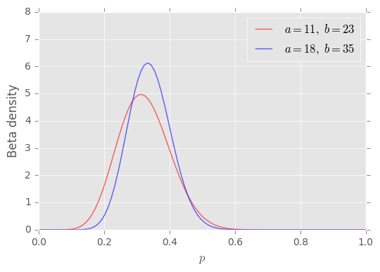

```python
ylim = (0, 8)
draw_beta(11, 23, 'r-', ylim)
draw_beta(18, 35, 'b-', ylim)
plt.xlabel('$p$')
plt.ylabel('Beta density')
plt.legend(loc='best')
```

## The Dirichlet Distribution

- The Dirichlet distribution is a multivariate extension of the Beta distribution.
- Whereas the Beta distribution is a distribution over Binomial distributions, the Dirichlet distribution is a distribution over Multinomial distributions.
- Mathematically, it is:

$$f\left(x_{1}, x_{2},\cdots ,x_{K};\alpha _{1}, \alpha_{2}, \cdots ,\alpha _{k}\right)={\frac {1}{\mathrm{B} (\alpha_{1}, \alpha_{2}, \cdots, \alpha_{k})}\prod _{i=1}^{K}x_{i}^{\alpha _{i}-1}}$$

- where $\mathrm{B}(\alpha_{1}, \alpha_{2}, \cdots, \alpha_{k})$ is the multivariate Beta function:

$$\mathrm {B}(\alpha_{1}, \alpha_{2}, \cdots, \alpha_{k})={\frac {\prod _{i=1}^{K}\Gamma (\alpha _{i})}{\Gamma \left(\sum _{i=1}^{K}\alpha _{i}\right)}}$$

- So:

$$f\left(x_{1}, x_{2},\cdots ,x_{K};\alpha _{1}, \alpha_{2}, \cdots ,\alpha _{k}\right)= {\frac{\Gamma \left(\sum _{i=1}^{K}\alpha _{i}\right)}{\prod _{i=1}^{K}\Gamma (\alpha _{i})}\prod _{i=1}^{K}x_{i}^{\alpha _{i}-1}}$$

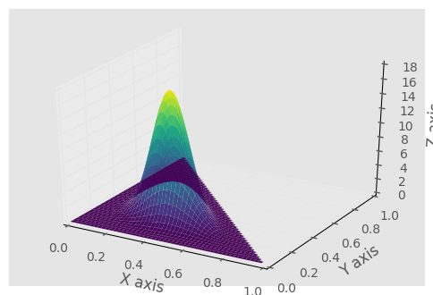

```python
# Based on https://www.mathworks.com/matlabcentral/newsreader/view_thread/139363

import numpy as np
import matplotlib
from mpl_toolkits.mplot3d import Axes3D

from scipy.special import gammaln

def draw_dirichlet(elev=None, azim=None):
    x1 = np.linspace(0, 1, 500, endpoint=True)
    x2 = np.linspace(0, 1, 500, endpoint=True)

    X1, X2 = np.meshgrid(x1, x2)
    X3 = 1 - (X1 + X2)
    bad = X1 + X2 > 1
    X1[bad] = np.nan
    X2[bad] = np.nan
    X3[bad] = np.nan

    alpha = [7, 7, 7]
    beta_const = np.exp(np.sum(gammaln(alpha))-gammaln(np.sum(alpha)))
    F = ((X1**(alpha[0]-1)) * (X2**(alpha[1]-1)) * (X3**(alpha[2]-1))) / beta_const

    fig = plt.figure(figsize=(6, 4))
    ax = fig.gca(projection='3d')
    norm = matplotlib.colors.Normalize(vmin = np.nanmin(F), vmax = np.nanmax(F), clip = False)
    ax.plot_surface(X1, X2, F, cmap='viridis', norm=norm, linewidth=0)
    ax.set_xlabel('X axis')
    ax.set_ylabel('Y axis')
    ax.set_zlabel('Z axis')
    ax.view_init(elev, azim)

draw_dirichlet()
```

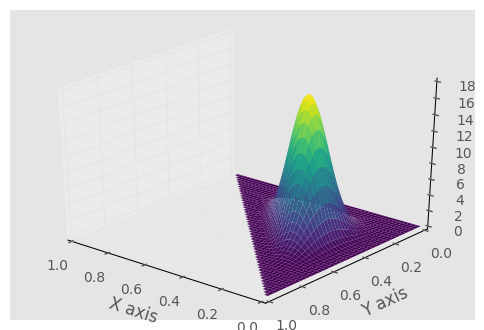

```python
draw_dirichlet(azim=130)
```

## The LDA Generative Process

- To generate a document:
  - Randomly choose a distribution over topics. These will be the topics of the document. The distribution used to choose the distribution of the topic documents is a Dirichlet distribution.
  - For each word that will enter the document:
    - Randomly choose a topic from the distribution of topics of the document (this is a multinomial distribution).
    - Randomly choose a word from the distribution over words that makes up the topic (this is a multinomial distribution).
    - Add the word in the document.

[figure not shown]

Figure taken from David M. Blei, Probabilistic Topic Models, Communications of the ACM, vol. 55, no. 4, pp. 77-84, April 2012.

[figure not shown]

Figure taken from David M. Blei, Probabilistic Topic Models, Communications of the ACM, vol. 55, no. 4, pp. 77-84, April 2012.

[figure not shown]

Figure taken from Mark Steyvers and Tom Griffiths, Probabilistic Topic Models, in T. Landauer, D McNamara, S. Dennis, W. Kintsch (eds), Latent Semantic Analysis: A Road to Meaning, Laurence Erlbaum, 2006.

```python
# Adapted from http://scikit-learn.org/stable/auto_examples/applications/topics_extraction_with_nmf_lda.html#sphx-glr-auto-examples-applications-topics-extraction-with-nmf-lda-py

from time import time

from sklearn.feature_extraction.text import TfidfVectorizer, CountVectorizer
from sklearn.decomposition import NMF, LatentDirichletAllocation
from sklearn.datasets import fetch_20newsgroups

n_samples = 2000
n_features = 1000
n_topics = 10
n_top_words = 20

def print_top_words(model, feature_names, n_top_words):
    for topic_idx, topic in enumerate(model.components_):
        print("Topic #%d:" % topic_idx)
        print(" ".join([feature_names[i]
                        for i in topic.argsort()[:-n_top_words - 1:-1]]))
    print()


# Load the 20 newsgroups dataset and vectorize it. We use a few heuristics
# to filter out useless terms early on: the posts are stripped of headers,
# footers and quoted replies, and common English words, words occurring in
# only one document or in at least 95% of the documents are removed.

print("Loading dataset...")
t0 = time()
dataset = fetch_20newsgroups(shuffle=True, random_state=1,
                             remove=('headers', 'footers', 'quotes'))
data_samples = dataset.data[:n_samples]
print("done in %0.3fs." % (time() - t0))

# Use tf (raw term count) features for LDA.
print("Extracting tf features for LDA...")
tf_vectorizer = CountVectorizer(max_df=0.95, min_df=2,
                                max_features=n_features,
                                stop_words='english')
t0 = time()
tf = tf_vectorizer.fit_transform(data_samples)
print("done in %0.3fs." % (time() - t0))

print("Fitting LDA models with tf features, "
      "n_samples=%d and n_features=%d..."
      % (n_samples, n_features))
lda = LatentDirichletAllocation(n_topics=n_topics, max_iter=5,
                                learning_method='online',
                                learning_offset=50.,
                                random_state=0)
t0 = time()
lda.fit(tf)
print("done in %0.3fs." % (time() - t0))

print("\nTopics in LDA model:")
tf_feature_names = tf_vectorizer.get_feature_names()
print_top_words(lda, tf_feature_names, n_top_words)
```

```
Loading dataset...
done in 1.967s.
Extracting tf features for LDA...
done in 0.441s.
Fitting LDA models with tf features, n_samples=2000 and n_features=1000...
done in 4.416s.

Topics in LDA model:
Topic #0:
edu com mail send graphics ftp pub available contact university list faq ca information cs 1993 program sun uk mit
Topic #1:
don like just know think ve way use right good going make sure ll point got need really time doesn
Topic #2:
christian think atheism faith pittsburgh new bible radio games alt lot just religion like book read play time subject believe
Topic #3:
drive disk windows thanks use card drives hard version pc software file using scsi help does new dos controller 16
Topic #4:
hiv health aids disease april medical care research 1993 light information study national service test led 10 page new drug
Topic #5:
god people does just good don jesus say israel way life know true fact time law want believe make think
Topic #6:
55 10 11 18 15 team game 19 period play 23 12 13 flyers 20 25 22 17 24 16
Topic #7:
car year just cars new engine like bike good oil insurance better tires 000 thing speed model brake driving performance
Topic #8:
people said did just didn know time like went think children came come don took years say dead told started
Topic #9:
key space law government public use encryption earth section security moon probe enforcement keys states lunar military crime surface technology
```